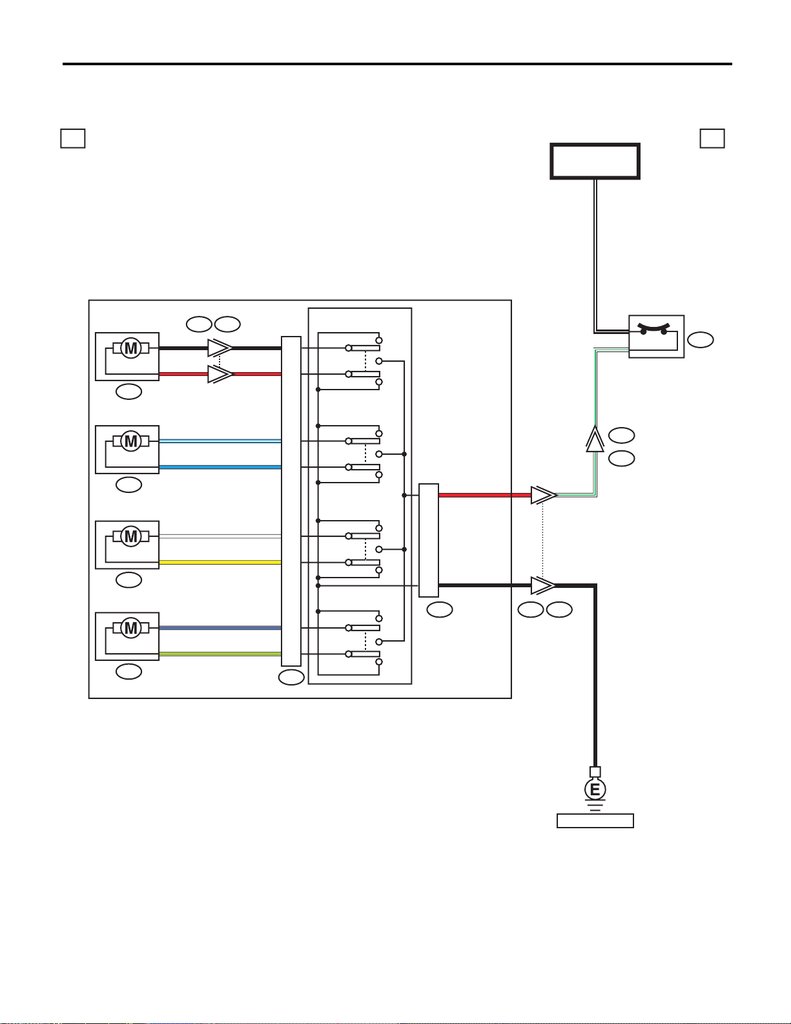

WI-322

Power Seat System

WIRING SYSTEM

36.Power Seat System

A: WIRING DIAGRAM

DOWN

UP

DOWN

UP

WI-44514

a a

6

4

5

1

4

6

1

4

6

4

10

5

8

7

3

2

6

9

B41

B99

R3

R200

R201

R202

R203

R204

R412 R411

2

1

1

2

1

B/W 2

W/G 1

W/G

B

R

B

B

R

L/W

L

W

Y

L/R

Y/L

B

R

B

W/G

MB-30

SBF-4

(B)

POWER SEAT SWITCH LH

POWER SEAT LH

LIFTER SWITCH

TILT SWITCH

SLIDE SWITCH

LIFTER MOTOR

TILT MOTOR

BACKWARD

FORWARD

BACKWARD

FORWARD

SLIDE MOTOR

RECLINING SWITCH

RECLINING MOTOR

POWER WINDOW

CIRCUIT BREAKER

REF. TO GND [f]

[figure not shown]

WI-323

Power Seat System

WIRING SYSTEM

LIST OF CONNECTORS

WI-44515

b b

B41

2

1

10 11

12 13 14 15 16 17 18 19 20 21 22 23 24

567

B99

R110

(B)

21

1

5

234

6789

10

R200

R204

R203

R201

123

645

R202

12345

R411

12